# Optimal Treatment Analysis

## Outcome Variable

**Outcome Variable:** haz

## Predictor Variables

**Intervention Variable:** exclfeed3

**Adjustment Set:**

- arm
- sex
- W_mage
- meducyrs
- feducyrs
- hhwealth_quart
- hfoodsec
- W_mhtcm
- vagbrth
- W_gagebrth
- W_birthwt
- W_birthlen
- W_nrooms
- W_nchldlt5
- month
- brthmon
- W_parity
- impfloor
- impsan
- safeh20
- delta_W_mage
- delta_meducyrs
- delta_feducyrs
- delta_hhwealth_quart
- delta_hfoodsec
- delta_W_mhtcm
- delta_vagbrth
- delta_W_gagebrth
- delta_W_birthwt
- delta_W_birthlen
- delta_W_nrooms
- delta_W_nchldlt5
- delta_month
- delta_brthmon
- delta_W_parity
- delta_impfloor
- delta_impsan
- delta_safeh20

## Stratifying Variables

The analysis was stratified on these variable(s):

- agecat
- studyid
- country

## Data Summary

| agecat | studyid | country | exclfeed3 | n_cell | n |
| --- | --- | --- | --- | --- | --- |
| Birth | ki0047075b-MAL-ED | BANGLADESH | 1 | 173 | 240 |
| Birth | ki0047075b-MAL-ED | BANGLADESH | 0 | 67 | 240 |
| Birth | ki0047075b-MAL-ED | BRAZIL | 1 | 67 | 185 |
| Birth | ki0047075b-MAL-ED | BRAZIL | 0 | 118 | 185 |
| Birth | ki0047075b-MAL-ED | INDIA | 1 | 123 | 196 |
| Birth | ki0047075b-MAL-ED | INDIA | 0 | 73 | 196 |
| Birth | ki0047075b-MAL-ED | NEPAL | 1 | 61 | 171 |
| Birth | ki0047075b-MAL-ED | NEPAL | 0 | 110 | 171 |
| Birth | ki0047075b-MAL-ED | PERU | 1 | 67 | 272 |
| Birth | ki0047075b-MAL-ED | PERU | 0 | 205 | 272 |
| Birth | ki0047075b-MAL-ED | SOUTH AFRICA | 1 | 32 | 233 |
| Birth | ki0047075b-MAL-ED | SOUTH AFRICA | 0 | 201 | 233 |
| Birth | ki0047075b-MAL-ED | TANZANIA, UNITED REPUBLIC OF | 1 | 39 | 119 |
| Birth | ki0047075b-MAL-ED | TANZANIA, UNITED REPUBLIC OF | 0 | 80 | 119 |
| Birth | ki1000108-CMC-V-BCS-2002 | INDIA | 1 | 4 | 4 |
| Birth | ki1000108-CMC-V-BCS-2002 | INDIA | 0 | 0 | 4 |
| Birth | ki1000108-IRC | INDIA | 1 | 0 | 10 |
| Birth | ki1000108-IRC | INDIA | 0 | 10 | 10 |
| Birth | ki1000109-EE | PAKISTAN | 1 | 2 | 2 |
| Birth | ki1000109-EE | PAKISTAN | 0 | 0 | 2 |
| Birth | ki1000304b-SAS-CompFeed | INDIA | 1 | 48 | 50 |
| Birth | ki1000304b-SAS-CompFeed | INDIA | 0 | 2 | 50 |
| Birth | ki1101329-Keneba | GAMBIA | 1 | 1196 | 1354 |
| Birth | ki1101329-Keneba | GAMBIA | 0 | 158 | 1354 |
| Birth | kiGH5241-JiVitA-3 | BANGLADESH | 1 | 16824 | 18710 |
| Birth | kiGH5241-JiVitA-3 | BANGLADESH | 0 | 1886 | 18710 |
| Birth | kiGH5241-JiVitA-4 | BANGLADESH | 1 | 37 | 40 |
| Birth | kiGH5241-JiVitA-4 | BANGLADESH | 0 | 3 | 40 |
| 6 months | ki0047075b-MAL-ED | BANGLADESH | 1 | 172 | 237 |
| 6 months | ki0047075b-MAL-ED | BANGLADESH | 0 | 65 | 237 |

[output cut: 58 more lines]

The following strata were considered:

- agecat: 24 months, studyid: ki0047075b-MAL-ED, country: BANGLADESH
- agecat: 24 months, studyid: ki0047075b-MAL-ED, country: BRAZIL
- agecat: 24 months, studyid: ki0047075b-MAL-ED, country: INDIA
- agecat: 24 months, studyid: ki0047075b-MAL-ED, country: NEPAL
- agecat: 24 months, studyid: ki0047075b-MAL-ED, country: PERU
- agecat: 24 months, studyid: ki0047075b-MAL-ED, country: SOUTH AFRICA
- agecat: 24 months, studyid: ki0047075b-MAL-ED, country: TANZANIA, UNITED REPUBLIC OF
- agecat: 24 months, studyid: ki1000108-CMC-V-BCS-2002, country: INDIA
- agecat: 24 months, studyid: ki1000108-IRC, country: INDIA
- agecat: 24 months, studyid: ki1017093b-PROVIDE, country: BANGLADESH
- agecat: 24 months, studyid: ki1101329-Keneba, country: GAMBIA
- agecat: 24 months, studyid: ki1113344-GMS-Nepal, country: NEPAL
- agecat: 24 months, studyid: kiGH5241-JiVitA-3, country: BANGLADESH
- agecat: 24 months, studyid: kiGH5241-JiVitA-4, country: BANGLADESH
- agecat: 6 months, studyid: ki0047075b-MAL-ED, country: BANGLADESH
- agecat: 6 months, studyid: ki0047075b-MAL-ED, country: BRAZIL
- agecat: 6 months, studyid: ki0047075b-MAL-ED, country: INDIA
- agecat: 6 months, studyid: ki0047075b-MAL-ED, country: NEPAL
- agecat: 6 months, studyid: ki0047075b-MAL-ED, country: PERU
- agecat: 6 months, studyid: ki0047075b-MAL-ED, country: SOUTH AFRICA
- agecat: 6 months, studyid: ki0047075b-MAL-ED, country: TANZANIA, UNITED REPUBLIC OF
- agecat: 6 months, studyid: ki1000108-CMC-V-BCS-2002, country: INDIA
- agecat: 6 months, studyid: ki1000108-IRC, country: INDIA
- agecat: 6 months, studyid: ki1000109-EE, country: PAKISTAN
- agecat: 6 months, studyid: ki1000304b-SAS-CompFeed, country: INDIA
- agecat: 6 months, studyid: ki1017093b-PROVIDE, country: BANGLADESH
- agecat: 6 months, studyid: ki1101329-Keneba, country: GAMBIA
- agecat: 6 months, studyid: ki1113344-GMS-Nepal, country: NEPAL
- agecat: 6 months, studyid: kiGH5241-JiVitA-3, country: BANGLADESH
- agecat: 6 months, studyid: kiGH5241-JiVitA-4, country: BANGLADESH
- agecat: Birth, studyid: ki0047075b-MAL-ED, country: BANGLADESH
- agecat: Birth, studyid: ki0047075b-MAL-ED, country: BRAZIL
- agecat: Birth, studyid: ki0047075b-MAL-ED, country: INDIA
- agecat: Birth, studyid: ki0047075b-MAL-ED, country: NEPAL
- agecat: Birth, studyid: ki0047075b-MAL-ED, country: PERU
- agecat: Birth, studyid: ki0047075b-MAL-ED, country: SOUTH AFRICA
- agecat: Birth, studyid: ki0047075b-MAL-ED, country: TANZANIA, UNITED REPUBLIC OF
- agecat: Birth, studyid: ki1000108-CMC-V-BCS-2002, country: INDIA
- agecat: Birth, studyid: ki1000108-IRC, country: INDIA
- agecat: Birth, studyid: ki1000109-EE, country: PAKISTAN
- agecat: Birth, studyid: ki1000304b-SAS-CompFeed, country: INDIA
- agecat: Birth, studyid: ki1101329-Keneba, country: GAMBIA
- agecat: Birth, studyid: kiGH5241-JiVitA-3, country: BANGLADESH
- agecat: Birth, studyid: kiGH5241-JiVitA-4, country: BANGLADESH

### Dropped Strata

Some strata were dropped due to rare outcomes:

- agecat: Birth, studyid: ki1000108-CMC-V-BCS-2002, country: INDIA
- agecat: Birth, studyid: ki1000108-IRC, country: INDIA
- agecat: Birth, studyid: ki1000109-EE, country: PAKISTAN
- agecat: Birth, studyid: ki1000304b-SAS-CompFeed, country: INDIA
- agecat: Birth, studyid: kiGH5241-JiVitA-4, country: BANGLADESH
- agecat: 6 months, studyid: ki1000108-CMC-V-BCS-2002, country: INDIA
- agecat: 6 months, studyid: ki1000108-IRC, country: INDIA
- agecat: 24 months, studyid: ki1000108-CMC-V-BCS-2002, country: INDIA
- agecat: 24 months, studyid: ki1000108-IRC, country: INDIA

## Methods Detail

We’re interested in the causal parameters $E[Y_a]$ for all values of $a \in \mathcal{A}$. These parameters represent the mean outcome if, possibly contrary to fact, we intervened to set all units to have $A=a$. Under the randomization and positivity assumptions, these are identified by the statistical parameters $\psi_a=E_W[E_{Y|A,W}(Y|A=a,W)]$. In addition, we’re interested in the mean of $Y$, $E[Y]$ under no intervention (the observed mean). We will estimate these parameters by using SuperLearner to fit the relevant likelihood factors – $E_{Y|A,W}(Y|A=a,W)$ and $p(A=a|W)$, and then updating our likelihood fit using a joint TMLE.

For unadjusted analyses ($W=\{\}$), initial likelihoods were estimated using Lrnr_glm to estimate the simple $E(Y|A)$ and Lrnr_mean to estimate $p(A)$. For adjusted analyses, a small library containing Lrnr_glmnet, Lrnr_xgboost, and Lrnr_mean was used.

Having estimated these parameters, we will then use the delta method to estimate relative risks and attributable risks relative to a prespecified baseline level of $A$.

# Results Detail

## Results Plots

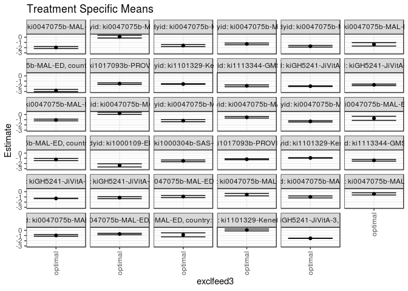

## Results Table

### Parameter: TSM

| agecat | studyid | country | intervention_level | baseline_level | estimate | ci_lower | ci_upper |
| --- | --- | --- | --- | --- | --- | --- | --- |
| Birth | ki0047075b-MAL-ED | BANGLADESH | optimal | observed | -0.9287286 | -1.1276760 | -0.7297812 |
| Birth | ki0047075b-MAL-ED | BRAZIL | optimal | observed | -0.5612779 | -0.7916026 | -0.3309532 |
| Birth | ki0047075b-MAL-ED | INDIA | optimal | observed | -0.9995922 | -1.1945053 | -0.8046791 |
| Birth | ki0047075b-MAL-ED | NEPAL | optimal | observed | -0.4150764 | -0.6261912 | -0.2039617 |
| Birth | ki0047075b-MAL-ED | PERU | optimal | observed | -0.9800869 | -1.1372084 | -0.8229654 |
| Birth | ki0047075b-MAL-ED | SOUTH AFRICA | optimal | observed | -0.7034380 | -0.8406811 | -0.5661950 |
| Birth | ki0047075b-MAL-ED | TANZANIA, UNITED REPUBLIC OF | optimal | observed | -0.8615480 | -1.2469007 | -0.4761954 |
| Birth | ki1101329-Keneba | GAMBIA | optimal | observed | 0.0706730 | -0.1098764 | 0.2512225 |
| Birth | kiGH5241-JiVitA-3 | BANGLADESH | optimal | observed | -1.5355813 | -1.5553714 | -1.5157911 |
| 6 months | ki0047075b-MAL-ED | BANGLADESH | optimal | observed | -1.0601818 | -1.2268221 | -0.8935415 |
| 6 months | ki0047075b-MAL-ED | BRAZIL | optimal | observed | 0.2307168 | 0.0321016 | 0.4293320 |
| 6 months | ki0047075b-MAL-ED | INDIA | optimal | observed | -1.1884512 | -1.3845892 | -0.9923133 |
| 6 months | ki0047075b-MAL-ED | NEPAL | optimal | observed | -0.5404092 | -0.6894222 | -0.3913961 |
| 6 months | ki0047075b-MAL-ED | PERU | optimal | observed | -1.3268158 | -1.4494141 | -1.2042175 |
| 6 months | ki0047075b-MAL-ED | SOUTH AFRICA | optimal | observed | -0.7369474 | -1.1344850 | -0.3394097 |
| 6 months | ki0047075b-MAL-ED | TANZANIA, UNITED REPUBLIC OF | optimal | observed | -1.2307903 | -1.4349508 | -1.0266298 |
| 6 months | ki1000109-EE | PAKISTAN | optimal | observed | -2.3647373 | -2.6697068 | -2.0597677 |
| 6 months | ki1000304b-SAS-CompFeed | INDIA | optimal | observed | -1.4877061 | -1.6531098 | -1.3223023 |
| 6 months | ki1017093b-PROVIDE | BANGLADESH | optimal | observed | -1.1802801 | -1.2734849 | -1.0870752 |
| 6 months | ki1101329-Keneba | GAMBIA | optimal | observed | -0.9285114 | -0.9824889 | -0.8745339 |
| 6 months | ki1113344-GMS-Nepal | NEPAL | optimal | observed | -1.3918049 | -1.5479274 | -1.2356824 |
| 6 months | kiGH5241-JiVitA-3 | BANGLADESH | optimal | observed | -1.2921554 | -1.3155411 | -1.2687698 |
| 6 months | kiGH5241-JiVitA-4 | BANGLADESH | optimal | observed | -1.1441783 | -1.3293782 | -0.9589784 |
| 24 months | ki0047075b-MAL-ED | BANGLADESH | optimal | observed | -1.9685749 | -2.1668578 | -1.7702920 |
| 24 months | ki0047075b-MAL-ED | BRAZIL | optimal | observed | 0.1185417 | -0.1464134 | 0.3834968 |
| 24 months | ki0047075b-MAL-ED | INDIA | optimal | observed | -1.5940956 | -1.7835996 | -1.4045917 |
| 24 months | ki0047075b-MAL-ED | NEPAL | optimal | observed | -1.2783420 | -1.4424173 | -1.1142666 |
| 24 months | ki0047075b-MAL-ED | PERU | optimal | observed | -1.7256690 | -1.8856713 | -1.5656668 |
| 24 months | ki0047075b-MAL-ED | SOUTH AFRICA | optimal | observed | -1.3691337 | -1.6959763 | -1.0422911 |
| 24 months | ki0047075b-MAL-ED | TANZANIA, UNITED REPUBLIC OF | optimal | observed | -2.8194346 | -3.0364743 | -2.6023949 |
| 24 months | ki1017093b-PROVIDE | BANGLADESH | optimal | observed | -1.4916727 | -1.6444077 | -1.3389377 |
| 24 months | ki1101329-Keneba | GAMBIA | optimal | observed | -1.5618507 | -1.6203460 | -1.5033553 |
| 24 months | ki1113344-GMS-Nepal | NEPAL | optimal | observed | -1.9169419 | -2.0957371 | -1.7381468 |
| 24 months | kiGH5241-JiVitA-3 | BANGLADESH | optimal | observed | -1.9808738 | -2.0398823 | -1.9218653 |
| 24 months | kiGH5241-JiVitA-4 | BANGLADESH | optimal | observed | -1.7177107 | -1.8616534 | -1.5737680 |

### Parameter: E(Y)

| agecat | studyid | country | intervention_level | baseline_level | estimate | ci_lower | ci_upper |
| --- | --- | --- | --- | --- | --- | --- | --- |
| Birth | ki0047075b-MAL-ED | BANGLADESH | observed | observed | -1.0497083 | -1.1780996 | -0.9213171 |
| Birth | ki0047075b-MAL-ED | BRAZIL | observed | observed | -0.7350811 | -0.8943683 | -0.5757938 |
| Birth | ki0047075b-MAL-ED | INDIA | observed | observed | -1.0098469 | -1.1519586 | -0.8677353 |
| Birth | ki0047075b-MAL-ED | NEPAL | observed | observed | -0.7128070 | -0.8704934 | -0.5551207 |
| Birth | ki0047075b-MAL-ED | PERU | observed | observed | -0.9261397 | -1.0389037 | -0.8133757 |
| Birth | ki0047075b-MAL-ED | SOUTH AFRICA | observed | observed | -0.7108584 | -0.8390511 | -0.5826657 |
| Birth | ki0047075b-MAL-ED | TANZANIA, UNITED REPUBLIC OF | observed | observed | -0.9205882 | -1.1394357 | -0.7017408 |
| Birth | ki1101329-Keneba | GAMBIA | observed | observed | 0.0135081 | -0.0559902 | 0.0830065 |
| Birth | kiGH5241-JiVitA-3 | BANGLADESH | observed | observed | -1.5457493 | -1.5650991 | -1.5263996 |
| 6 months | ki0047075b-MAL-ED | BANGLADESH | observed | observed | -1.2009705 | -1.3199485 | -1.0819924 |
| 6 months | ki0047075b-MAL-ED | BRAZIL | observed | observed | 0.0510207 | -0.0930194 | 0.1950608 |
| 6 months | ki0047075b-MAL-ED | INDIA | observed | observed | -1.2109514 | -1.3300505 | -1.0918522 |
| 6 months | ki0047075b-MAL-ED | NEPAL | observed | observed | -0.5557940 | -0.6681063 | -0.4434817 |
| 6 months | ki0047075b-MAL-ED | PERU | observed | observed | -1.3229136 | -1.4307207 | -1.2151065 |
| 6 months | ki0047075b-MAL-ED | SOUTH AFRICA | observed | observed | -1.0640356 | -1.1937663 | -0.9343049 |
| 6 months | ki0047075b-MAL-ED | TANZANIA, UNITED REPUBLIC OF | observed | observed | -1.3516458 | -1.4765824 | -1.2267092 |
| 6 months | ki1000109-EE | PAKISTAN | observed | observed | -2.2056604 | -2.3285064 | -2.0828144 |
| 6 months | ki1000304b-SAS-CompFeed | INDIA | observed | observed | -1.4697236 | -1.6333919 | -1.3060553 |
| 6 months | ki1017093b-PROVIDE | BANGLADESH | observed | observed | -1.0871041 | -1.1635539 | -1.0106543 |
| 6 months | ki1101329-Keneba | GAMBIA | observed | observed | -0.9489317 | -1.0001696 | -0.8976937 |
| 6 months | ki1113344-GMS-Nepal | NEPAL | observed | observed | -1.3235298 | -1.4103807 | -1.2366790 |
| 6 months | kiGH5241-JiVitA-3 | BANGLADESH | observed | observed | -1.3060279 | -1.3292905 | -1.2827653 |
| 6 months | kiGH5241-JiVitA-4 | BANGLADESH | observed | observed | -1.2339326 | -1.4137041 | -1.0541611 |
| 24 months | ki0047075b-MAL-ED | BANGLADESH | observed | observed | -1.9391587 | -2.0665449 | -1.8117724 |
| 24 months | ki0047075b-MAL-ED | BRAZIL | observed | observed | 0.0418343 | -0.1253834 | 0.2090521 |
| 24 months | ki0047075b-MAL-ED | INDIA | observed | observed | -1.8433556 | -1.9704665 | -1.7162446 |
| 24 months | ki0047075b-MAL-ED | NEPAL | observed | observed | -1.2693778 | -1.3896188 | -1.1491367 |
| 24 months | ki0047075b-MAL-ED | PERU | observed | observed | -1.7440201 | -1.8648503 | -1.6231899 |
| 24 months | ki0047075b-MAL-ED | SOUTH AFRICA | observed | observed | -1.6114440 | -1.7486349 | -1.4742530 |
| 24 months | ki0047075b-MAL-ED | TANZANIA, UNITED REPUBLIC OF | observed | observed | -2.6159762 | -2.7525555 | -2.4793968 |
| 24 months | ki1017093b-PROVIDE | BANGLADESH | observed | observed | -1.5861179 | -1.6693668 | -1.5028689 |
| 24 months | ki1101329-Keneba | GAMBIA | observed | observed | -1.5804688 | -1.6348908 | -1.5260468 |
| 24 months | ki1113344-GMS-Nepal | NEPAL | observed | observed | -1.8788036 | -1.9703700 | -1.7872372 |
| 24 months | kiGH5241-JiVitA-3 | BANGLADESH | observed | observed | -2.0111797 | -2.0396837 | -1.9826758 |
| 24 months | kiGH5241-JiVitA-4 | BANGLADESH | observed | observed | -1.7671053 | -1.9017670 | -1.6324435 |

### Parameter: PAR

| agecat | studyid | country | intervention_level | baseline_level | estimate | ci_lower | ci_upper |
| --- | --- | --- | --- | --- | --- | --- | --- |
| Birth | ki0047075b-MAL-ED | BANGLADESH | optimal | observed | -0.1209798 | -0.2813912 | 0.0394317 |
| Birth | ki0047075b-MAL-ED | BRAZIL | optimal | observed | -0.1738032 | -0.3721895 | 0.0245831 |
| Birth | ki0047075b-MAL-ED | INDIA | optimal | observed | -0.0102547 | -0.1629953 | 0.1424858 |
| Birth | ki0047075b-MAL-ED | NEPAL | optimal | observed | -0.2977306 | -0.4878382 | -0.1076230 |
| Birth | ki0047075b-MAL-ED | PERU | optimal | observed | 0.0539472 | -0.0721558 | 0.1800501 |
| Birth | ki0047075b-MAL-ED | SOUTH AFRICA | optimal | observed | -0.0074203 | -0.0512317 | 0.0363911 |
| Birth | ki0047075b-MAL-ED | TANZANIA, UNITED REPUBLIC OF | optimal | observed | -0.0590402 | -0.3268349 | 0.2087545 |
| Birth | ki1101329-Keneba | GAMBIA | optimal | observed | -0.0571649 | -0.2239562 | 0.1096264 |
| Birth | kiGH5241-JiVitA-3 | BANGLADESH | optimal | observed | -0.0101681 | -0.0154110 | -0.0049251 |
| 6 months | ki0047075b-MAL-ED | BANGLADESH | optimal | observed | -0.1407887 | -0.2742421 | -0.0073353 |
| 6 months | ki0047075b-MAL-ED | BRAZIL | optimal | observed | -0.1796960 | -0.3177806 | -0.0416115 |
| 6 months | ki0047075b-MAL-ED | INDIA | optimal | observed | -0.0225001 | -0.1542428 | 0.1092426 |
| 6 months | ki0047075b-MAL-ED | NEPAL | optimal | observed | -0.0153848 | -0.1358728 | 0.1051032 |
| 6 months | ki0047075b-MAL-ED | PERU | optimal | observed | 0.0039022 | -0.0724402 | 0.0802446 |
| 6 months | ki0047075b-MAL-ED | SOUTH AFRICA | optimal | observed | -0.3270883 | -0.6980266 | 0.0438500 |
| 6 months | ki0047075b-MAL-ED | TANZANIA, UNITED REPUBLIC OF | optimal | observed | -0.1208555 | -0.2893834 | 0.0476724 |
| 6 months | ki1000109-EE | PAKISTAN | optimal | observed | 0.1590769 | -0.1309280 | 0.4490818 |
| 6 months | ki1000304b-SAS-CompFeed | INDIA | optimal | observed | 0.0179824 | -0.0394213 | 0.0753861 |
| 6 months | ki1017093b-PROVIDE | BANGLADESH | optimal | observed | 0.0931760 | 0.0260350 | 0.1603170 |
| 6 months | ki1101329-Keneba | GAMBIA | optimal | observed | -0.0204203 | -0.0393009 | -0.0015396 |
| 6 months | ki1113344-GMS-Nepal | NEPAL | optimal | observed | 0.0682751 | -0.0582133 | 0.1947635 |
| 6 months | kiGH5241-JiVitA-3 | BANGLADESH | optimal | observed | -0.0138725 | -0.0208542 | -0.0068907 |
| 6 months | kiGH5241-JiVitA-4 | BANGLADESH | optimal | observed | -0.0897543 | -0.1774260 | -0.0020825 |
| 24 months | ki0047075b-MAL-ED | BANGLADESH | optimal | observed | 0.0294163 | -0.1488797 | 0.2077122 |
| 24 months | ki0047075b-MAL-ED | BRAZIL | optimal | observed | -0.0767074 | -0.2617114 | 0.1082966 |
| 24 months | ki0047075b-MAL-ED | INDIA | optimal | observed | -0.2492599 | -0.3991305 | -0.0993894 |
| 24 months | ki0047075b-MAL-ED | NEPAL | optimal | observed | 0.0089642 | -0.1010274 | 0.1189557 |
| 24 months | ki0047075b-MAL-ED | PERU | optimal | observed | -0.0183511 | -0.1421060 | 0.1054039 |
| 24 months | ki0047075b-MAL-ED | SOUTH AFRICA | optimal | observed | -0.2423103 | -0.5586415 | 0.0740210 |
| 24 months | ki0047075b-MAL-ED | TANZANIA, UNITED REPUBLIC OF | optimal | observed | 0.2034584 | 0.0210419 | 0.3858749 |
| 24 months | ki1017093b-PROVIDE | BANGLADESH | optimal | observed | -0.0944452 | -0.2211841 | 0.0322937 |
| 24 months | ki1101329-Keneba | GAMBIA | optimal | observed | -0.0186181 | -0.0413449 | 0.0041086 |
| 24 months | ki1113344-GMS-Nepal | NEPAL | optimal | observed | 0.0381383 | -0.1177535 | 0.1940302 |
| 24 months | kiGH5241-JiVitA-3 | BANGLADESH | optimal | observed | -0.0303059 | -0.0813623 | 0.0207505 |
| 24 months | kiGH5241-JiVitA-4 | BANGLADESH | optimal | observed | -0.0493945 | -0.0871877 | -0.0116014 |